# Retail Sales Data Analysis using Python

## Project Objective

This project performs end-to-end exploratory data analysis (EDA) on a retail sales dataset to uncover business insights related to sales performance, profitability, customer behavior, and regional trends.

## Tools Used

- Pandas → Data manipulation and cleaning
- NumPy → Numerical operations
- Matplotlib → Static visualizations
- Seaborn → Statistical plots
- Plotly → Interactive visualizations

## Dataset Description

- Source : Superstore Sales Dataset
- Category : Large transactional dataset Retail Dataset containing sales transactions, customer, product, and regional information.
- Business Domain : Retail / E-Commerce Analytics

## Key Goals

- Data Cleaning & Preparation
- Exploratory Data Analysis (EDA)
- Feature Engineering
- Profitability & Loss Analysis
- Customer & Product Insights
- Business Recommendations

## Section 1 : Business Understanding

### Key Business Questions :

- How are sales and profits trending over time?
- Which regions and categories are most profitable?
- Which products cause losses?
- Who are the top customers?
- Which segments drive maximum revenue?
- Are there seasonal patterns?
- Where is the business leaking money?

## Section 2 : Import Libraries

```python
import pandas as pd
import numpy as np
import matplotlib.pyplot as plt
import seaborn as sns
import plotly.express as px
import plotly.io as pio
pio.renderers.default = "notebook_connected"

import warnings
warnings.filterwarnings("ignore")
```

## Section 3 : Data Loading & Initial Exploration

```python
df = pd.read_excel("C:\Data Set\Superstore.xlsx")
df
```

|  | Row ID | Order ID | Order Date | Ship Date | Ship Mode | Customer ID | Customer Name | Segment | Country/Region | City | ... | Postal Code | Region | Product ID | Category | Sub-Category | Product Name | Sales | Quantity | Discount | Profit |
| --- | --- | --- | --- | --- | --- | --- | --- | --- | --- | --- | --- | --- | --- | --- | --- | --- | --- | --- | --- | --- | --- |
| 0 | 1 | CA-2020-152156 | 2022-03-22 | 2020-11-11 | Second Class | CG-12520 | Claire Gute | Consumer | United States | Henderson | ... | 42420.0 | West | FUR-BO-10001798 | Furniture | Bookcases | Bush Somerset Collection Bookcase | 261.9600 | 2 | 0.00 | 41.9136 |
| 1 | 2 | CA-2020-152156 | 2020-11-08 | 2020-11-11 | Second Class | CG-12520 | Claire Gute | Consumer | United States | Henderson | ... | 42420.0 | West | FUR-CH-10000454 | Furniture | Fasteners | Hon Deluxe Fabric Upholstered Stacking Chairs,... | 731.9400 | 3 | 0.00 | 219.5820 |
| 2 | 3 | CA-2020-138688 | 2020-06-12 | 2020-06-16 | Second Class | DV-13045 | Darrin Van Huff | Corporate | United States | Los Angeles | ... | 90036.0 | West | OFF-LA-10000240 | Office Supplies | Fasteners | Self-Adhesive Address Labels for Typewriters b... | 14.6200 | 2 | 0.00 | 6.8714 |
| 3 | 4 | US-2019-108966 | 2019-10-11 | 2019-10-18 | Standard Class | SO-20335 | Sean O'Donnell | Consumer | United States | Fort Lauderdale | ... | 33311.0 | West | FUR-TA-10000577 | Furniture | Fasteners | Bretford CR4500 Series Slim Rectangular Table | 957.5775 | 5 | 0.45 | -383.0310 |
| 4 | 5 | US-2019-108966 | 2019-10-11 | 2019-10-18 | Standard Class | SO-20335 | Sean O'Donnell | Consumer | United States | Fort Lauderdale | ... | 33311.0 | West | OFF-ST-10000760 | Office Supplies | Fasteners | Eldon Fold 'N Roll Cart System | 22.3680 | 2 | 0.20 | 2.5164 |
| ... | ... | ... | ... | ... | ... | ... | ... | ... | ... | ... | ... | ... | ... | ... | ... | ... | ... | ... | ... | ... | ... |
| 9989 | 9990 | CA-2018-110422 | 2022-01-21 | 2022-01-23 | Second Class | TB-21400 | Tom Boeckenhauer | Consumer | United States | Miami | ... | 33180.0 | West | FUR-FU-10001889 | Furniture | Furnishings | Ultra Door Pull Handle | 25.2480 | 3 | 0.20 | 4.1028 |
| 9990 | 9991 | CA-2021-121258 | 2021-02-26 | 2021-03-03 | Standard Class | DB-13060 | Dave Brooks | Consumer | United States | Costa Mesa | ... | 92627.0 | West | FUR-FU-10000747 | Furniture | Furnishings | Tenex B1-RE Series Chair Mats for Low Pile Car... | 91.9600 | 2 | 0.00 | 15.6332 |
| 9991 | 9992 | CA-2021-121258 | 2021-02-26 | 2021-03-03 | Standard Class | DB-13060 | Dave Brooks | Consumer | United States | Costa Mesa | ... | 92627.0 | West | TEC-PH-10003645 | Technology | Phones | Aastra 57i VoIP phone | 258.5760 | 2 | 0.20 | 19.3932 |
| 9992 | 9993 | CA-2021-121258 | 2021-02-26 | 2021-03-03 | Standard Class | DB-13060 | Dave Brooks | Consumer | United States | Costa Mesa | ... | 92627.0 | West | OFF-PA-10004041 | Office Supplies | Paper | It's Hot Message Books with Stickers, 2 3/4" x 5" | 29.6000 | 4 | 0.00 | 13.3200 |
| 9993 | 9994 | CA-2021-119914 | 2021-05-04 | 2021-05-09 | Second Class | CC-12220 | Chris Cortes | Consumer | United States | Westminster | ... | 92683.0 | West | OFF-AP-10002684 | Office Supplies | Appliances | Acco 7-Outlet Masterpiece Power Center, Wihtou... | 243.1600 | 2 | 0.00 | 72.9480 |

9994 rows × 21 columns

# Initial Exploration of Dataset

```python
df.shape
```

```
(9994, 21)
```

```python
df.columns
```

```
Index(['Row ID', 'Order ID', 'Order Date', 'Ship Date', 'Ship Mode',
       'Customer ID', 'Customer Name', 'Segment', 'Country/Region', 'City',
       'State', 'Postal Code', 'Region', 'Product ID', 'Category',
       'Sub-Category', 'Product Name', 'Sales', 'Quantity', 'Discount',
       'Profit'],
      dtype='object')
```

```python
df.info()
```

```
<class 'pandas.core.frame.DataFrame'>
RangeIndex: 9994 entries, 0 to 9993
Data columns (total 21 columns):
 #   Column          Non-Null Count  Dtype
---  ------          --------------  -----
 0   Row ID          9994 non-null   int64
 1   Order ID        9994 non-null   object
 2   Order Date      9994 non-null   datetime64[ns]
 3   Ship Date       9994 non-null   datetime64[ns]
 4   Ship Mode       9994 non-null   object
 5   Customer ID     9994 non-null   object
 6   Customer Name   9994 non-null   object
 7   Segment         9994 non-null   object
 8   Country/Region  9994 non-null   object
 9   City            9994 non-null   object
 10  State           9994 non-null   object
 11  Postal Code     9987 non-null   float64
 12  Region          9994 non-null   object
 13  Product ID      9994 non-null   object
 14  Category        9994 non-null   object
 15  Sub-Category    9994 non-null   object
 16  Product Name    9994 non-null   object
 17  Sales           9994 non-null   float64
 18  Quantity        9994 non-null   int64
 19  Discount        9994 non-null   float64
 20  Profit          9994 non-null   float64
dtypes: datetime64[ns](2), float64(4), int64(2), object(13)
memory usage: 1.6+ MB
```

```python
df.describe(include="all")
```

|  | Row ID | Order ID | Order Date | Ship Date | Ship Mode | Customer ID | Customer Name | Segment | Country/Region | City | ... | Postal Code | Region | Product ID | Category | Sub-Category | Product Name | Sales | Quantity | Discount | Profit |
| --- | --- | --- | --- | --- | --- | --- | --- | --- | --- | --- | --- | --- | --- | --- | --- | --- | --- | --- | --- | --- | --- |
| count | 9994.000000 | 9994 | 9994 | 9994 | 9994 | 9994 | 9994 | 9994 | 9994 | 9994 | ... | 9987.000000 | 9994 | 9994 | 9994 | 9994 | 9994 | 9994.000000 | 9994.000000 | 9994.000000 | 9994.000000 |
| unique | NaN | 5009 | NaN | NaN | 4 | 793 | 793 | 3 | 1 | 531 | ... | NaN | 4 | 1862 | 3 | 17 | 1849 | NaN | NaN | NaN | NaN |
| top | NaN | CA-2021-100111 | NaN | NaN | Standard Class | WB-21850 | William Brown | Consumer | United States | New York City | ... | NaN | West | OFF-PA-10001970 | Office Supplies | Binders | Staple envelope | NaN | NaN | NaN | NaN |
| freq | NaN | 14 | NaN | NaN | 5968 | 37 | 37 | 5191 | 9994 | 915 | ... | NaN | 3215 | 19 | 6026 | 1521 | 48 | NaN | NaN | NaN | NaN |
| mean | 4997.500000 | NaN | 2021-02-15 09:45:59.975985664 | 2021-02-11 13:36:58.210926848 | NaN | NaN | NaN | NaN | NaN | NaN | ... | 55258.046861 | NaN | NaN | NaN | NaN | NaN | 229.858001 | 3.789574 | 0.156203 | 28.656896 |
| min | 1.000000 | NaN | 2019-01-02 00:00:00 | 2019-01-01 00:00:00 | NaN | NaN | NaN | NaN | NaN | NaN | ... | 1040.000000 | NaN | NaN | NaN | NaN | NaN | 0.444000 | 1.000000 | 0.000000 | -6599.978000 |
| 25% | 2499.250000 | NaN | 2020-04-10 00:00:00 | 2020-04-05 00:00:00 | NaN | NaN | NaN | NaN | NaN | NaN | ... | 23223.000000 | NaN | NaN | NaN | NaN | NaN | 17.280000 | 2.000000 | 0.000000 | 1.728750 |
| 50% | 4997.500000 | NaN | 2021-03-08 00:00:00 | 2021-03-02 00:00:00 | NaN | NaN | NaN | NaN | NaN | NaN | ... | 57103.000000 | NaN | NaN | NaN | NaN | NaN | 54.490000 | 3.000000 | 0.200000 | 8.666500 |
| 75% | 7495.750000 | NaN | 2021-11-26 00:00:00 | 2021-11-27 00:00:00 | NaN | NaN | NaN | NaN | NaN | NaN | ... | 90008.000000 | NaN | NaN | NaN | NaN | NaN | 209.940000 | 5.000000 | 0.200000 | 29.364000 |
| max | 9994.000000 | NaN | 2022-12-31 00:00:00 | 2022-12-31 00:00:00 | NaN | NaN | NaN | NaN | NaN | NaN | ... | 99301.000000 | NaN | NaN | NaN | NaN | NaN | 22638.480000 | 14.000000 | 0.800000 | 8399.976000 |
| std | 2885.163629 | NaN | NaN | NaN | NaN | NaN | NaN | NaN | NaN | NaN | ... | 32038.565553 | NaN | NaN | NaN | NaN | NaN | 623.245101 | 2.225110 | 0.206452 | 234.260108 |

11 rows × 21 columns

### Initial Observations

- Dataset contains 9994 Rows and 21 Columns
- Some missing values present
- Datatype of Postal Code column is not Correct
- Sales and Profit show high variance

## Section 4 : Data Quality Assessment, Cleaning and Transforming

```python
# Creating a copy before any Permanent Change of original dataset
df1 = df.copy()
```

```python
# Finding Missing Values Column-wise
df.isnull().sum()
```

```
Row ID            0
Order ID          0
Order Date        0
Ship Date         0
Ship Mode         0
Customer ID       0
Customer Name     0
Segment           0
Country/Region    0
City              0
State             0
Postal Code       7
Region            0
Product ID        0
Category          0
Sub-Category      0
Product Name      0
Sales             0
Quantity          0
Discount          0
Profit            0
dtype: int64
```

```python
# As we don't know the Exact Postal Code and deleting entire Rows is not expeted,
# So replacing Null values to integer Zero will be better for furthur calculation.
df1["Postal Code"].fillna(0, inplace=True)

df1["Postal Code"].isnull().sum()
```

```
np.int64(0)
```

```python
# Changing Postal Code column from Float to Integer
df1["Postal Code"].astype(int)
```

```
0       42420
1       42420
2       90036
3       33311
4       33311
        ...
9989    33180
9990    92627
9991    92627
9992    92627
9993    92683
Name: Postal Code, Length: 9994, dtype: int64
```

```python
# Duplicate Records
df1.drop_duplicates()

df1.duplicated().sum()
```

```
np.int64(0)
```

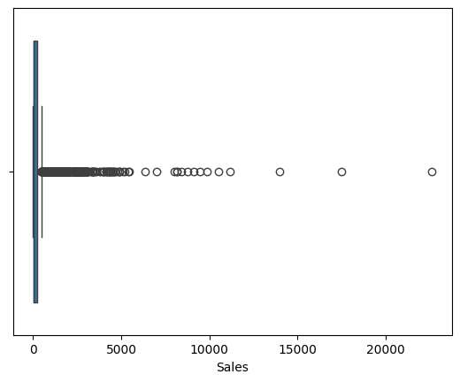

```python
# Outlier Detection (Sales & Profit)
sns.boxplot(x=df1["Sales"])
```

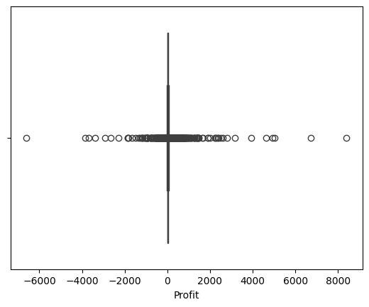

```python
sns.boxplot(x=df1["Profit"])
```

```python
# Date Formatting
df1["Order Date"] = pd.to_datetime(df1["Order Date"])
df1["Ship Date"] = pd.to_datetime(df1["Ship Date"])
```

```python
# Handle Invalid Values
df1 = df1[df1["Sales"]>0]
```

## Section 5 : Feature Engineering (Creating New Columns for KPI)

```python
# Creating a copy before any Permanent Change of original dataset
df2 = df1.copy()
```

```python
df2["Order Year"] = df2["Order Date"].dt.year
df2["Order Year"]
```

```
0       2022
1       2020
2       2020
3       2019
4       2019
        ...
9989    2022
9990    2021
9991    2021
9992    2021
9993    2021
Name: Order Year, Length: 9994, dtype: int32
```

```python
df2["Order Quater"] = df2["Order Date"].dt.to_period("Q")
df2["Order Quater"]
```

```
0       2022Q1
1       2020Q4
2       2020Q2
3       2019Q4
4       2019Q4
         ...
9989    2022Q1
9990    2021Q1
9991    2021Q1
9992    2021Q1
9993    2021Q2
Name: Order Quater, Length: 9994, dtype: period[Q-DEC]
```

```python
df2["Order Month"] = df2["Order Date"].dt.month
df2["Order Month"]
```

```
0        3
1       11
2        6
3       10
4       10
        ..
9989     1
9990     2
9991     2
9992     2
9993     5
Name: Order Month, Length: 9994, dtype: int32
```

```python
df2["Delivery Time"] = (df2["Ship Date"]-df2["Order Date"]).dt.days
df2["Delivery Time"]
```

```
0      -496
1         3
2         4
3         7
4         7
       ...
9989      2
9990      5
9991      5
9992      5
9993      5
Name: Delivery Time, Length: 9994, dtype: int64
```

```python
# Handle Invalid Values
df2 = df2[df2["Delivery Time"]>0]
```

### New features created to support KPI and performance analysis:

- Profit Margin
- Shipping Delay
- Year, Quater and Month

## Section 6 : Univariate Analysis

```
count     9421.000000
mean       229.080448
std        627.544531
min          0.444000
25%         17.248000
50%         54.224000
75%        209.700000
max      22638.480000
Name: Sales, dtype: float64
```

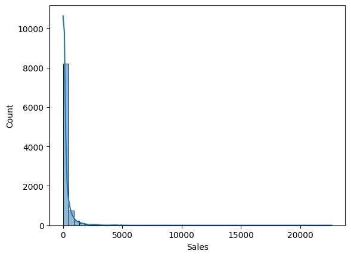

```python
# Distribution of Sales
print(df2["Sales"].describe())

sns.histplot(
    df2["Sales"],
    bins = 50,
    kde = True
)
```

```
Segment
Consumer       4866
Corporate      2885
Home Office    1670
Name: count, dtype: int64
```

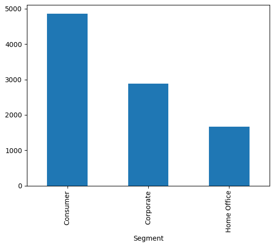

```python
# Segment Distribution
print(df2["Segment"].value_counts())

df2["Segment"].value_counts().plot(kind="bar")
```

## Step 7 : Bivariate Analysis

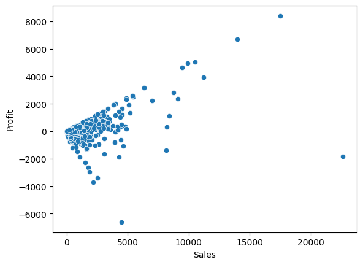

```python
# Sales vs Profit
sns.scatterplot(
    data = df2,
    x = "Sales",
    y = "Profit",
)
```

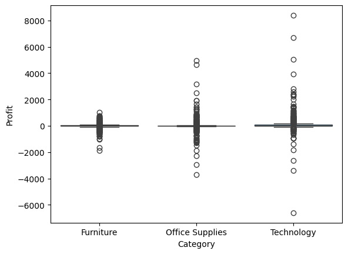

```python
# Category vs Profit
sns.boxplot(
    data = df2,
    x = "Category",
    y = "Profit"
)
```

## Section 8 : Multivariate Analysis

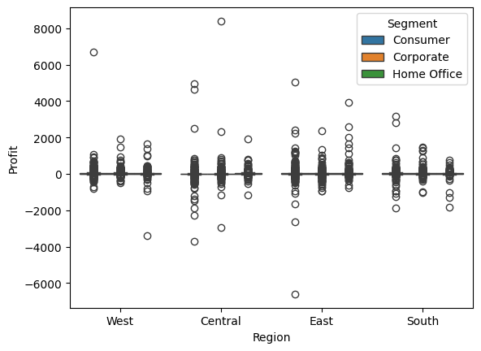

```python
# Region and Segment wise Profit
sns.boxplot(
    data = df2,
    x = "Region",
    y = "Profit",
    hue = "Segment"
)
```

## Step 9 : Time Series Analysis

```
Order Month
1      94186.1466
2      57542.7514
3     194592.4778
4     134774.3046
5     146592.7787
6     145457.5863
7     131704.2860
8     153816.0210
9     289477.3287
10    185833.2147
11    327782.7670
12    296407.2415
Name: Sales, dtype: float64
```

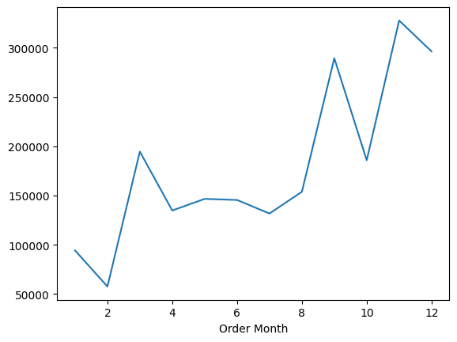

```python
# Monthly Sales Trends
monthly_sales = df2.groupby(df2["Order Month"])["Sales"].sum()
print(monthly_sales)
monthly_sales.plot(
    kind = "line"
)
```

```
Order Year
2019    443195.7910
2020    575016.7410
2021    686846.9912
2022    453107.3811
Name: Sales, dtype: float64
```

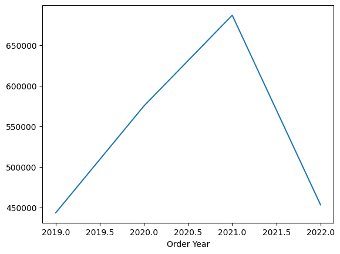

```python
# Year-Over-Year Growth
yearly_sales = df2.groupby(df2["Order Year"])["Sales"].sum()
print(yearly_sales)
yearly_sales.plot(
    kind = "line"
)
```

## Step 10 : Customer Segmentation Analysis

```
Customer Name
Sean Miller           25035.082
Tamara Chand          18530.298
Raymond Buch          15117.339
Tom Ashbrook          14595.620
Adrian Barton         14473.571
Sanjit Chand          14142.334
Ken Lonsdale          14076.877
Hunter Lopez          12873.298
Sanjit Engle          12209.438
Christopher Conant    12129.072
Todd Sumrall          11891.751
Greg Tran             11820.120
Becky Martin          11789.630
Seth Vernon           11470.950
Caroline Jumper       11164.974
Maria Etezadi         10663.728
Karen Ferguson        10604.266
Edward Hooks          10255.980
Bill Shonely           9614.550
Clay Ludtke            9415.302
Name: Sales, dtype: float64
```

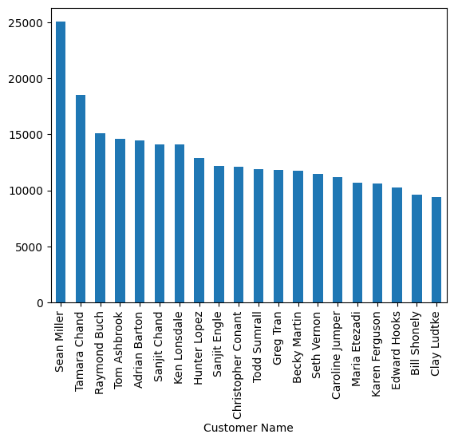

```python
# Top 20 Customers
top_cust = df2.groupby(df2["Customer Name"])["Sales"].sum().sort_values(ascending=False).head(20)
print(top_cust)
top_cust.plot(
    kind = "bar"
)
```

```python
# Top Loss-Making States
df[df['Profit'] < 0].groupby('State')['Profit'].sum().sort_values().head(10)
```

```
State
Texas            -36813.1875
Ohio             -21750.0002
Pennsylvania     -21602.8515
Illinois         -19501.6975
North Carolina   -11557.9854
Colorado          -8900.9048
Florida           -8689.8295
Tennessee         -7257.0174
Arizona           -6656.7675
New York          -5031.1378
Name: Profit, dtype: float64
```

## Step 11 : Product Performance Analysis

```
                       Sales       Profit
Category
Furniture        701069.0563   17630.3074
Office Supplies  684876.9160  115548.4510
Technology       772220.9320  135539.1326
```

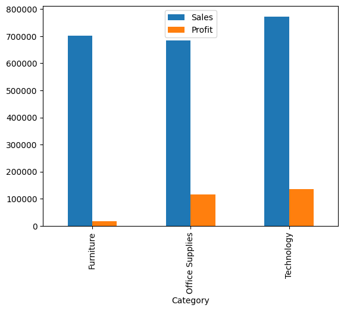

```python
# Category level Performance
clp = df2.groupby("Category")[["Sales", "Profit"]].sum()
print(clp)
clp.plot(
    kind = "bar"
)
```

```python
# Sub-Category Loss Analysis
df2[df2["Profit"]<0].groupby("Sub-Category")["Profit"].sum().sort_values()
```

```
Sub-Category
Binders       -37413.4391
Tables        -30343.1344
Machines      -25888.0904
Bookcases     -12147.3668
Chairs         -8850.4546
Appliances     -8215.3710
Phones         -6988.7507
Storage        -6255.8166
Furnishings    -5880.5904
Supplies       -3015.6219
Accessories     -914.9572
Fasteners       -540.0842
Name: Profit, dtype: float64
```

## Step 12 : Loss & Risk Analysis

```python
# Order with Negetive Profit Margin
df2["profit_margin"] = (df2["Profit"]/df2["Sales"])*100

df2[df2["profit_margin"]<0].sort_values(by="profit_margin").head(20)
```

|  | Row ID | Order ID | Order Date | Ship Date | Ship Mode | Customer ID | Customer Name | Segment | Country/Region | City | ... | Product Name | Sales | Quantity | Discount | Profit | Order Year | Order Quater | Order Month | Delivery Time | profit_margin |
| --- | --- | --- | --- | --- | --- | --- | --- | --- | --- | --- | --- | --- | --- | --- | --- | --- | --- | --- | --- | --- | --- |
| 261 | 262 | US-2021-155299 | 2021-06-08 | 2021-06-12 | Standard Class | Dl-13600 | Dorris liebe | Corporate | United States | Pasadena | ... | Eureka Disposable Bags for Sanitaire Vibra Gro... | 1.624 | 2 | 0.8 | -4.4660 | 2021 | 2021Q2 | 6 | 4 | -275.0 |
| 9164 | 9165 | CA-2019-164007 | 2019-06-08 | 2019-06-12 | Standard Class | MG-17695 | Maureen Gnade | Consumer | United States | Chicago | ... | Hoover Shoulder Vac Commercial Portable Vacuum | 143.128 | 2 | 0.8 | -393.6020 | 2019 | 2019Q2 | 6 | 4 | -275.0 |
| 8766 | 8767 | CA-2019-107083 | 2019-11-21 | 2019-11-27 | Standard Class | BB-11545 | Brenda Bowman | Corporate | United States | Fort Worth | ... | Kensington 6 Outlet SmartSocket Surge Protector | 24.588 | 3 | 0.8 | -67.6170 | 2019 | 2019Q4 | 11 | 6 | -275.0 |
| 676 | 677 | US-2021-119438 | 2021-03-18 | 2021-03-23 | Standard Class | CD-11980 | Carol Darley | Consumer | United States | Tyler | ... | Hoover Portapower Portable Vacuum | 2.688 | 3 | 0.8 | -7.3920 | 2021 | 2021Q1 | 3 | 5 | -275.0 |
| 6561 | 6562 | CA-2021-144680 | 2021-03-31 | 2021-04-02 | First Class | SC-20260 | Scott Cohen | Corporate | United States | Arlington | ... | Fellowes 8 Outlet Superior Workstation Surge P... | 33.620 | 5 | 0.8 | -90.7740 | 2021 | 2021Q1 | 3 | 2 | -270.0 |
| 5414 | 5415 | US-2021-125647 | 2021-09-23 | 2021-09-28 | Standard Class | LC-16870 | Lena Cacioppo | Consumer | United States | Chicago | ... | Euro Pro Shark Stick Mini Vacuum | 73.176 | 6 | 0.8 | -197.5752 | 2021 | 2021Q3 | 9 | 5 | -270.0 |
| 4980 | 4981 | US-2020-131114 | 2020-12-09 | 2020-12-13 | Second Class | RW-19630 | Rob Williams | Corporate | United States | Chicago | ... | Belkin 6 Outlet Metallic Surge Strip | 4.356 | 2 | 0.8 | -11.7612 | 2020 | 2020Q4 | 12 | 4 | -270.0 |
| 8916 | 8917 | US-2020-144057 | 2020-05-09 | 2020-05-13 | Standard Class | CV-12805 | Cynthia Voltz | Corporate | United States | Austin | ... | Euro Pro Shark Stick Mini Vacuum | 48.784 | 4 | 0.8 | -131.7168 | 2020 | 2020Q2 | 5 | 4 | -270.0 |
| 9086 | 9087 | CA-2020-143406 | 2020-09-26 | 2020-09-30 | Standard Class | LR-17035 | Lisa Ryan | Corporate | United States | Houston | ... | Hoover Commercial Lightweight Upright Vacuum w... | 93.032 | 2 | 0.8 | -251.1864 | 2020 | 2020Q3 | 9 | 4 | -270.0 |
| 6989 | 6990 | CA-2021-165099 | 2021-12-11 | 2021-12-13 | First Class | DK-13375 | Dennis Kane | Consumer | United States | Abilene | ... | Hoover Commercial Lightweight Upright Vacuum | 1.392 | 2 | 0.8 | -3.7584 | 2021 | 2021Q4 | 12 | 2 | -270.0 |
| 6903 | 6904 | CA-2021-111220 | 2021-09-02 | 2021-09-08 | Standard Class | JS-15595 | Jill Stevenson | Corporate | United States | Chicago | ... | Belkin 7-Outlet SurgeMaster Home Series | 5.588 | 2 | 0.8 | -15.0876 | 2021 | 2021Q3 | 9 | 6 | -270.0 |
| 6034 | 6035 | US-2019-155369 | 2019-04-19 | 2019-04-25 | Standard Class | PG-18820 | Patrick Gardner | Consumer | United States | Carrollton | ... | Fellowes Premier Superior Surge Suppressor, 10... | 19.568 | 2 | 0.8 | -52.8336 | 2019 | 2019Q2 | 4 | 6 | -270.0 |
| 8981 | 8982 | CA-2020-110898 | 2020-03-06 | 2020-03-12 | Standard Class | LC-16870 | Lena Cacioppo | Consumer | United States | Chicago | ... | Commercial WindTunnel Clean Air Upright Vacuum... | 2.334 | 3 | 0.8 | -6.3018 | 2020 | 2020Q1 | 3 | 6 | -270.0 |
| 203 | 204 | US-2021-116701 | 2021-12-17 | 2021-12-21 | Second Class | LC-17140 | Logan Currie | Consumer | United States | Dallas | ... | Eureka Sanitaire Commercial Upright | 66.284 | 2 | 0.8 | -178.9668 | 2021 | 2021Q4 | 12 | 4 | -270.0 |
| 5755 | 5756 | CA-2018-163748 | 2022-10-14 | 2022-10-18 | Standard Class | HG-15025 | Hunter Glantz | Consumer | United States | Fort Worth | ... | Hoover Replacement Belts For Soft Guard & Comm... | 3.160 | 4 | 0.8 | -8.5320 | 2022 | 2022Q4 | 10 | 4 | -270.0 |
| 4437 | 4438 | CA-2020-163398 | 2020-05-03 | 2020-05-08 | Standard Class | CB-12415 | Christy Brittain | Consumer | United States | Chicago | ... | Acco Smartsocket Color-Coded Six-Outlet AC Ada... | 26.406 | 3 | 0.8 | -71.2962 | 2020 | 2020Q2 | 5 | 5 | -270.0 |
| 7494 | 7495 | US-2021-160836 | 2021-09-11 | 2021-09-16 | Standard Class | CC-12475 | Cindy Chapman | Consumer | United States | Houston | ... | Commercial WindTunnel Clean Air Upright Vacuum... | 1.556 | 2 | 0.8 | -4.2012 | 2021 | 2021Q3 | 9 | 5 | -270.0 |
| 6251 | 6252 | CA-2018-101147 | 2022-12-02 | 2022-12-04 | First Class | MC-17575 | Matt Collins | Consumer | United States | Chicago | ... | Staple holder | 2.394 | 1 | 0.8 | -6.3441 | 2022 | 2022Q4 | 12 | 2 | -265.0 |
| 8112 | 8113 | CA-2020-130393 | 2020-12-01 | 2020-12-03 | Second Class | JM-15865 | John Murray | Consumer | United States | San Angelo | ... | Acco 6 Outlet Guardian Premium Surge Suppressor | 11.648 | 4 | 0.8 | -30.8672 | 2020 | 2020Q4 | 12 | 2 | -265.0 |
| 8959 | 8960 | CA-2021-150266 | 2021-11-25 | 2021-11-30 | Standard Class | RO-19780 | Rose O'Brian | Consumer | United States | Houston | ... | Fellowes Command Center 5-outlet power strip | 67.840 | 5 | 0.8 | -179.7760 | 2021 | 2021Q4 | 11 | 5 | -265.0 |

20 rows × 26 columns

```python
# Region-wise Loss
df2[df2["profit_margin"]<0].groupby("Region")["Profit"].sum()
```

```
Region
Central   -54241.6866
East      -47011.6424
South     -22918.8641
West      -22281.4842
Name: Profit, dtype: float64
```

## Section 13 : Advanced Interactive Visuals

```python
# Profit Margin by Category
fig = px.box(
    df2,
    x="Category",
    y="profit_margin",
    color="Category"
)
fig.show()
```

[interactive chart not shown]

```python
# Average Profit Margin by Category
margin_cat = df2.groupby("Category", as_index=False)["profit_margin"].mean()

fig = px.bar(
    margin_cat,
    x="Category",
    y="profit_margin",
    color="profit_margin",
    text_auto=True,
    title="Average Profit Margin by Category"
)
fig.show()
```

[interactive chart not shown]

```python
# Average Profit Margin by Region
margin_reg = df2.groupby("Region", as_index=False)["profit_margin"].mean()

fig = px.bar(
    margin_reg,
    x="Region",
    y="profit_margin",
    color="profit_margin",
    text_auto=True,
    title="Average Profit Margin by Region"
)
fig.show()
```

[interactive chart not shown]

```python
# Profit Margin vs Discount
fig = px.scatter(
    df2,
    x="Discount",
    y="profit_margin",
    color="Category",
    title="Profit Margin vs Discount",
)
fig.show()
```

[interactive chart not shown]

## Section 14 : Correlation Heatmap

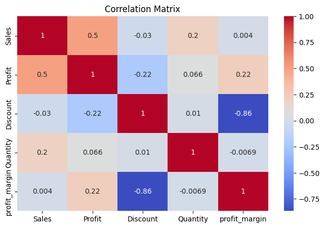

```python
plt.figure(figsize=(8,5))
sns.heatmap(df2[['Sales','Profit','Discount','Quantity','profit_margin']].corr(),
            annot=True, cmap='coolwarm')
plt.title("Correlation Matrix")
plt.show()
```

Discount negatively impacts profit margin, indicating excessive discounting reduces profitability.

## Section 15 : Final Business Insights and Recommendations

### Key Business Insights

- Technology category drives highest profit.
- Some sub-categories generate consistent losses.
- Consumer segment contributes majority of sales.
- Sales show seasonal growth pattern.
- A small number of customers generate large revenue.

### Business Recommendations

- Optimize pricing for loss-making products
- Focus marketing on high-profit customers
- Improve shipping efficiency in high-delay orders
- Strengthen high-performing regions and categories